# Rdionica: priprema datoteke `podaci_upitnik.csv` za obradu

Pomoću `miss_case_summary` možemo dobiti informaciju o tome koliko svaki pojedini sudionik ima missinga.

```r
podaci_na %>%
# gledamo samo prvih 20
slice(1:20) %>%
naniar::miss_case_summary(.)
## # A tibble: 20 x 3
##     case n_miss pct_miss
##    <int>  <int>    <dbl>
##  1    13     12    18.2
##  2     2      7    10.6
##  3     3      7    10.6
##  4     5      7    10.6
##  5    12      7    10.6
##  6    16      7    10.6
##  7    18      7    10.6
##  8     6      6     9.09
##  9     9      6     9.09
## 10     8      5     7.58
## 11    14      5     7.58
## 12    17      5     7.58
## 13    20      5     7.58
## 14     1      4     6.06
## 15     4      4     6.06
## 16    10      4     6.06
## 17    15      4     6.06
## 18    19      4     6.06
## 19    11      3     4.55
## 20     7      2     3.03
```

Ove funkcije su zgodne za opći pregled. Ako želimo pobliže ispitati obrasce nedostajućih podataka, trebamo ući dublje u odnose među pojedinim varijablama. Prva funkcija koja nam ovdje uskače upomoć dolazi iz `naniara`.

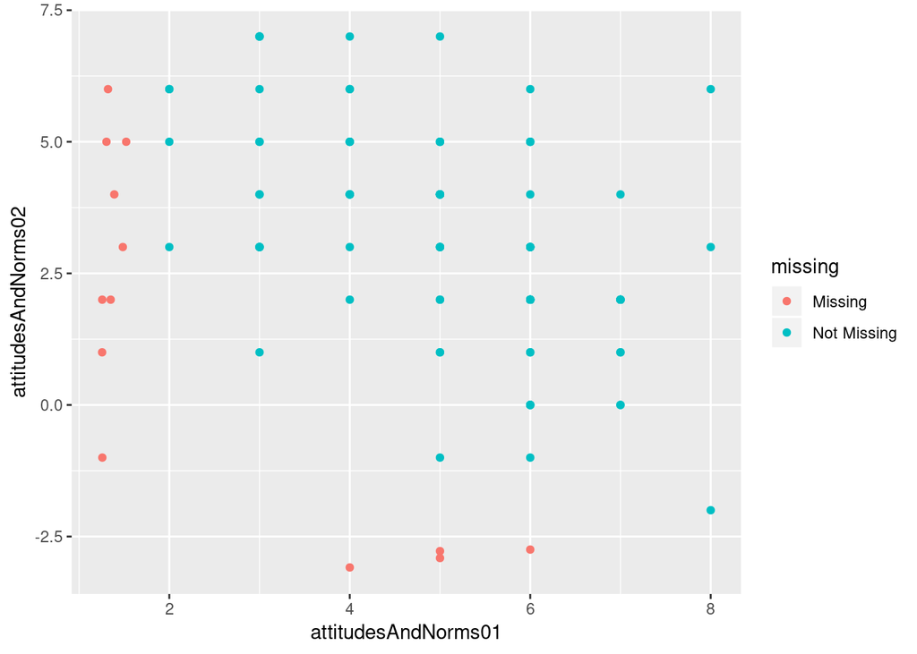

```r
ggplot2::ggplot(podaci_na, aes(x = attitudesAndNorms01,
                     y = attitudesAndNorms02)) +
       naniar::geom_miss_point()
```

Točke označene kao `Missing` imaju vrijednost na osi (tj. varijabli) kojoj su priklonjene (tj. s kojom su paralelne), ali nemaju na varijabli na koju su okomite.

`Missing` točke nalaze se ispod minimuma koji vrijednosti dosežu na skali na kojoj nemaju rezultat. Da bude jasnije:

```r
podaci_na %>%
dplyr::select(., attitudesAndNorms01, attitudesAndNorms02) %>%
summary(.)
##  attitudesAndNorms01 attitudesAndNorms02
##  Min.   :2.000       Min.   :-2.000
##  1st Qu.:4.000       1st Qu.: 2.000
##  Median :5.000       Median : 3.000
##  Mean   :5.055       Mean   : 3.198
##  3rd Qu.:6.000       3rd Qu.: 5.000
##  Max.   :8.000       Max.   : 7.000
##  NA's   :9           NA's   :4
```

Vidimo da je minimum na `attitudesAndNorms01` 2, a na `attitudesAndNorms02` -2. Missing vrijednosti na grafu se nalaze ispod tih vrijednosti. `gg_miss_upset` daje nam prikaz obrasca povezanosti missing vrijednosti kroz varijable.

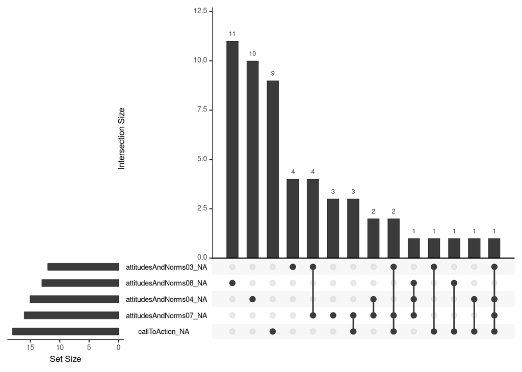

```r
podaci_na %>%
dplyr::select(., 1:10) %>%
naniar::gg_miss_upset(., nsets = 5, nintersect = 18)
```

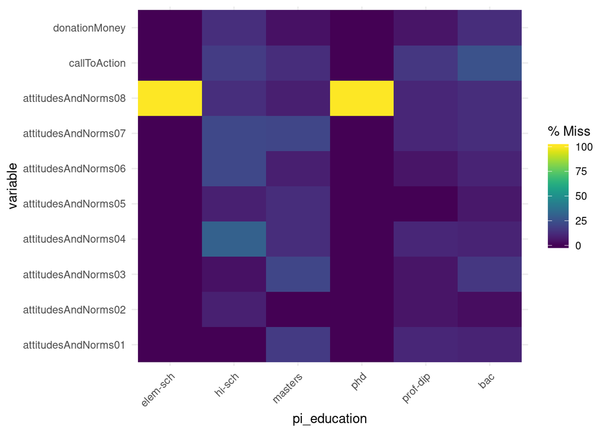

```r
podaci_na %>%
dplyr::select(., 1:10, pi_education) %>%
naniar::gg_miss_fct(., fct = pi_education)
```

Ovdje, recimo, možemo vidjeti da nitko ili gotovo nitko tko je završio osnovnu školu ili doktorat nije odgovorio na osmo pitanje u `attitudesAndNorms08`, što nije pretjerano zabrinjavajuće jer su podaci simulirani, ali bi se u stvarnoj situaciji čovjek možda htio zapitati.

# Prtljanje po podacima iz SPSS-a za opće dobro

Kao što je na početku najavljeno, proći ćemo kroz R-ovsko prtljanje po korumpiranim podacima iz SPSS-a.

```r
head(podaci_spss)
## # A tibble: 6 x 65
##   attitudesAndNor… attitudesAndNor… attitudesAndNor… attitudesAndNor…
##              <dbl>            <dbl>            <dbl>            <dbl>
## 1                5                5                5                5
## 2                5                4                2                1
## 3                4                6                5                5
## 4                6                2                3                2
## 5                4                1                2                3
## 6                4                4                4                3
## # … with 61 more variables: attitudesAndNorms05 <dbl>,
## #   attitudesAndNorms06 <dbl>, attitudesAndNorms07 <dbl>,
## #   attitudesAndNorms08 <dbl>, callToAction <dbl>,
## #   charitableBehavior01 <dbl>, charitableBehavior02 <dbl>,
## #   descriptiveSocialNorms01 <dbl>, descriptiveSocialNorms02 <dbl>,
## #   descriptiveSocialNorms03 <dbl>, descriptiveSocialNorms04 <dbl>,
## #   mf_AuthoritySubversion <dbl>, mf_CareHarm <dbl>,
## #   mf_FairnessCheating <dbl>, mf_LoyaltyBetrayal <dbl>,
## #   mf_SanctityDegradation <dbl>, moralFoundations01 <dbl>,
## #   moralFoundations02 <dbl>, moralFoundations03 <dbl>,
## #   moralFoundations04 <dbl>, moralFoundations05 <dbl>,
## #   moralFoundations06 <dbl>, moralFoundations07 <dbl>,
## #   moralFoundations08 <dbl>, moralFoundations09 <dbl>,
## #   moralFoundations10 <dbl>, moralFoundations11 <dbl>,
## #   moralFoundations12 <dbl>, moralFoundations13 <dbl>,
## #   moralFoundations14 <dbl>, moralFoundations15 <dbl>,
## #   moralFoundations16 <dbl>, moralFoundations17 <dbl>,
## #   moralFoundations18 <dbl>, moralFoundations19 <dbl>,
## #   moralFoundations20 <dbl>, moralFoundations21 <dbl>,
## #   moralFoundations22 <dbl>, moralFoundations23 <dbl>,
## #   moralFoundations24 <dbl>, moralFoundations25 <dbl>,
## #   moralFoundations26 <dbl>, moralFoundations27 <dbl>,
## #   moralFoundations28 <dbl>, moralFoundations29 <dbl>,
## #   moralFoundations30 <dbl>, moralFoundations31 <dbl>,
## #   moralFoundations32 <dbl>, moralIdentityInternalization01 <dbl>,
## #   moralIdentityInternalization02 <dbl>,
## #   moralIdentityInternalization03 <dbl>,
## #   moralIdentityInternalization04 <dbl>,
## #   moralIdentityInternalization05 <dbl>, pi_age <dbl>,
## #   pi_education <chr>, pi_gender <chr>, pi_ideology <chr>,
## #   pi_income <chr>, pi_nationality <chr>, pi_previousDonations <chr>,
## #   V65 <chr>
```

```r
podaci_spss %>%
dplyr::filter(., str_detect(.$pi_gender, 'degree')) ->
podaci_spss_korumpirani
```

Zatim, filtiramo originalni `data.frame`, tako da u njemu ostaju samo redovi koji nisu korumpirani, odnosno oni koji nemaju string *degree*. Možemo samo kopipejstati raniji kod i pred poziv `str_detect` staviti uskličnik, koji je simbol za negaciju (pretvorit će vektor iz `TRUE, FALSE, TRUE, ...` u `FALSE, TRUE, FALSE, ...`). Također, mičemo upisivanje u novu varijablu, i pipu mijenjamo u assignment pipu.

```r
podaci_spss %<>%
dplyr::filter(., !str_detect(.$pi_gender, 'degree'))
```

Sad trebamo popraviti unose u `podaci_spss_korumpirano` i popravljene unose prilijepiti na `podaci_spss`.

```r
head(podaci_spss_korumpirani)
## # A tibble: 6 x 65
##   attitudesAndNor… attitudesAndNor… attitudesAndNor… attitudesAndNor…
##              <dbl>            <dbl>            <dbl>            <dbl>
## 1                5                5                5                5
## 2                6                0                3                3
## 3                5                7                7                6
## 4                2                3                3                2
## 5                6                0                3                1
## 6                6                5                3                2
## # … with 61 more variables: attitudesAndNorms05 <dbl>,
## #   attitudesAndNorms06 <dbl>, attitudesAndNorms07 <dbl>,
## #   attitudesAndNorms08 <dbl>, callToAction <dbl>,
## #   charitableBehavior01 <dbl>, charitableBehavior02 <dbl>,
## #   descriptiveSocialNorms01 <dbl>, descriptiveSocialNorms02 <dbl>,
## #   descriptiveSocialNorms03 <dbl>, descriptiveSocialNorms04 <dbl>,
## #   mf_AuthoritySubversion <dbl>, mf_CareHarm <dbl>,
## #   mf_FairnessCheating <dbl>, mf_LoyaltyBetrayal <dbl>,
## #   mf_SanctityDegradation <dbl>, moralFoundations01 <dbl>,
## #   moralFoundations02 <dbl>, moralFoundations03 <dbl>,
## #   moralFoundations04 <dbl>, moralFoundations05 <dbl>,
## #   moralFoundations06 <dbl>, moralFoundations07 <dbl>,
## #   moralFoundations08 <dbl>, moralFoundations09 <dbl>,
## #   moralFoundations10 <dbl>, moralFoundations11 <dbl>,
## #   moralFoundations12 <dbl>, moralFoundations13 <dbl>,
## #   moralFoundations14 <dbl>, moralFoundations15 <dbl>,
## #   moralFoundations16 <dbl>, moralFoundations17 <dbl>,
## #   moralFoundations18 <dbl>, moralFoundations19 <dbl>,
## #   moralFoundations20 <dbl>, moralFoundations21 <dbl>,
## #   moralFoundations22 <dbl>, moralFoundations23 <dbl>,
## #   moralFoundations24 <dbl>, moralFoundations25 <dbl>,
## #   moralFoundations26 <dbl>, moralFoundations27 <dbl>,
## #   moralFoundations28 <dbl>, moralFoundations29 <dbl>,
## #   moralFoundations30 <dbl>, moralFoundations31 <dbl>,
## #   moralFoundations32 <dbl>, moralIdentityInternalization01 <dbl>,
## #   moralIdentityInternalization02 <dbl>,
## #   moralIdentityInternalization03 <dbl>,
## #   moralIdentityInternalization04 <dbl>,
## #   moralIdentityInternalization05 <dbl>, pi_age <dbl>,
## #   pi_education <chr>, pi_gender <chr>, pi_ideology <chr>,
## #   pi_income <chr>, pi_nationality <chr>, pi_previousDonations <chr>,
## #   V65 <chr>
```

Sredit ćemo si `dput` output da si uštedimo neko tipkanje u kasnijim koracima.

```r
podaci_spss_korumpirani %>%
dplyr::select(., pi_gender:V65) %>%
colnames(.) %>%
dput(.)
## c("pi_gender", "pi_ideology", "pi_income", "pi_nationality",
## "pi_previousDonations", "V65")
```

Za sređivanje stupaca možemo iskoristiti malo zgodnog prtljanja s `unite` i `separate` funkcijama. `unite` radi točno ono što nam treba - uzima $n$ stupaca i spaja ih u jedan novi (onaj definiran pod arugmentom `col`). Vrijednosti iz različitih stupaca odvaja stringom navedenim pod `sep`. Po difoltu, stupci koje spajamo se brišu te ostaje samo novi stupac. To ponašanje možemo mijenjati putem argumenta `remove`. U ovom slučaju, to je okej, pa ćemo ostaviti difolt argument.

Želimo spojiti unose pod `pi_education` i `pi_gender` u `pi_education`. Kao `sep` ćemo koristiti prazan string. Dakle, radimo sljedeće:

```r
podaci_spss_korumpirani %>%
tidyr::unite(.,
            # novi stupac
            col = pi_education,
            # stupci koje spajamo
            pi_education, pi_gender,
            # separator
            sep = '') %>%
# ovaj dio je samo za fokusiranje outputa
dplyr::select(., pi_education:ncol(.)) %>%
head(.)
## # A tibble: 6 x 6
##   pi_education  pi_ideology pi_income pi_nationality pi_previousDona… V65
##   <chr>         <chr>       <chr>     <chr>          <chr>            <chr>
## 1 "\"Some prof… Male        Neither … Somewhat belo… American         Rare…
## 2 "\"Some prof… Female      Somewhat… Somewhat abov… American         Regu…
## 3 "\"Some prof… Female      Very lib… Somewhat belo… Canadian         Rare…
## 4 "\"Some prof… Female      Very lib… Somewhat abov… American         Often
## 5 "\"Some prof… Female      Very lib… Somewhat abov… American         Often
## 6 "\"Some prof… Female      Somewhat… Much below th… British          Rare…
```

Vidimo da su vrijednosti pod `pi_education` točne, ali sad imena varijabli ne odgovaraju njihovom sadržaju. Na primjer, spol se nalazi pod `pi_ideology`. Kako ne bismo morali mijenjati ime svake pojedine varijable, iskoristiti ćemo moći koje nam nudi funkcija `separate`. Ona uzima jedan stupac i razdvaja ga na $n$ stupaca na temelju separatora `sep`. Novi stupci dobivaju imena definirana pod `into`. Stoga, možemo prvo uzeti sve preostale stupce - od `pi_ideology` do `V65` - i spojiti ih u jedan stupac - `tmp` (kao, *temporary*). Kao `sep` ćemo korsititi `@@`, budući da se taj string vrlo vjerojato neće naći nigdje u vrijednostima varijabli. Mogli bismo uzeti bilo koji drugi simbol za koji smo sigurni da se ne pojavljuje.

```r
podaci_spss_korumpirani %>%
tidyr::unite(., col = pi_education,
            pi_education:pi_gender,
            sep = '') %>%
tidyr::unite(.,col = tmp,
            pi_ideology:V65,
            sep = '@@') %>%
dplyr::select(., pi_education:ncol(.)) %>%
head(.)
## # A tibble: 6 x 2
##   pi_education                  tmp
##   <chr>                         <chr>
## 1 "\"Some professional diploma… Male@@Neither liberal or conservative@@Som…
## 2 "\"Some professional diploma… Female@@Somewhat liberal (left)@@Somewhat …
## 3 "\"Some professional diploma… Female@@Very liberal (left)@@Somewhat belo…
## 4 "\"Some professional diploma… Female@@Very liberal (left)@@Somewhat abov…
## 5 "\"Some professional diploma… Female@@Very liberal (left)@@Somewhat abov…
## 6 "\"Some professional diploma… Female@@Somewhat liberal (left)@@Much belo…
```

Dobili smo novi stupac `tmp` koji sadrži ružne stringove. Sad ćemo iskoristiti `separate` kako bismo vrijednosti u tom stupcu podijelili po separatoru `@@`. U argument `into` ćemo kopipejstati output funkcije `dput` koji smo ranije priredili, pri čemu ćemo obrisati posljednji unos (`V65`) jer to ne želimo gledati u konačnoj tablici.

```r
podaci_spss_korumpirani %>%
tidyr::unite(., col = pi_education,
            pi_education:pi_gender,
            sep = '') %>%
tidyr::unite(.,col = tmp,
            pi_ideology:V65,
            sep = '@@') %>%
tidyr::separate(., col = tmp,
               # ovo je output funkcije dput koju smo
               # pozvali ranije, bez posljednjeg unosa,
               # V65
               into = c("pi_gender", "pi_ideology",
                        "pi_income", "pi_nationality",
                        "pi_previousDonations"),
               sep = '@@') %>%
dplyr::select(., pi_education:ncol(.)) %>%
head(.)
## # A tibble: 6 x 6
##   pi_education pi_gender pi_ideology pi_income pi_nationality
##   <chr>        <chr>     <chr>       <chr>     <chr>
## 1 "\"Some pro… Male      Neither li… Somewhat… American
## 2 "\"Some pro… Female    Somewhat l… Somewhat… American
## 3 "\"Some pro… Female    Very liber… Somewhat… Canadian
## 4 "\"Some pro… Female    Very liber… Somewhat… American
## 5 "\"Some pro… Female    Very liber… Somewhat… American
## 6 "\"Some pro… Female    Somewhat l… Much bel… British
## # … with 1 more variable: pi_previousDonations <chr>
```

Sad imamo ispravno posložene stupce. Možemo maknuti nepotrebne navodnike iz unosa pod `pi_education` koristeći `mutate_at` da na taj stupac primijenimo funkciju `str_replace_all`.

```r
podaci_spss_korumpirani %>%
tidyr::unite(., col = pi_education,
            pi_education:pi_gender,
            sep = '') %>%
tidyr::unite(.,col = tmp,
            pi_ideology:V65,
            sep = '@@') %>%
tidyr::separate(., col = tmp,
               into = c("pi_gender", "pi_ideology",
                        "pi_income", "pi_nationality",
                        "pi_previousDonations"),
               sep = '@@') %>%
dplyr::mutate_at(., .vars = vars(pi_education),
                .f = stringr::str_replace_all,
                pattern = '"', replacement = '') %>%
dplyr::select(., pi_education:ncol(.)) %>%
head(.)
## # A tibble: 6 x 6
##   pi_education pi_gender pi_ideology pi_income pi_nationality
##   <chr>        <chr>     <chr>       <chr>     <chr>
## 1 Some profes… Male      Neither li… Somewhat… American
## 2 Some profes… Female    Somewhat l… Somewhat… American
## 3 Some profes… Female    Very liber… Somewhat… Canadian
## 4 Some profes… Female    Very liber… Somewhat… American
## 5 Some profes… Female    Very liber… Somewhat… American
## 6 Some profes… Female    Somewhat l… Much bel… British
## # … with 1 more variable: pi_previousDonations <chr>
```

Sad kad smo zadovoljni outputom našeg pipelinea, spremit ćemo promjene.

NB: Moramo maknuti zadnje dvije linije (koje smo koristili za fokusiranje outputa) jer će inače `podaci_spss_korumpirano` sadržavati samo ovo što vidimo gore.

```r
podaci_spss_korumpirani %<>%
tidyr::unite(., col = pi_education,
            pi_education:pi_gender,
            sep = '') %>%
tidyr::unite(.,col = tmp,
            pi_ideology:V65,
            sep = '@@') %>%
tidyr::separate(., col = tmp,
               into = c("pi_gender", "pi_ideology",
                        "pi_income", "pi_nationality",
                        "pi_previousDonations"),
               sep = '@@') %>%
dplyr::mutate_at(., .vars = vars(pi_education),
                .f = stringr::str_replace_all,
                pattern = '"', replacement = '')

head(podaci_spss_korumpirani)
## # A tibble: 6 x 64
##   attitudesAndNor… attitudesAndNor… attitudesAndNor… attitudesAndNor…
##              <dbl>            <dbl>            <dbl>            <dbl>
## 1                5                5                5                5
## 2                6                0                3                3
## 3                5                7                7                6
## 4                2                3                3                2
## 5                6                0                3                1
## 6                6                5                3                2
## # … with 60 more variables: attitudesAndNorms05 <dbl>,
## #   attitudesAndNorms06 <dbl>, attitudesAndNorms07 <dbl>,
## #   attitudesAndNorms08 <dbl>, callToAction <dbl>,
## #   charitableBehavior01 <dbl>, charitableBehavior02 <dbl>,
## #   descriptiveSocialNorms01 <dbl>, descriptiveSocialNorms02 <dbl>,
## #   descriptiveSocialNorms03 <dbl>, descriptiveSocialNorms04 <dbl>,
## #   mf_AuthoritySubversion <dbl>, mf_CareHarm <dbl>,
## #   mf_FairnessCheating <dbl>, mf_LoyaltyBetrayal <dbl>,
## #   mf_SanctityDegradation <dbl>, moralFoundations01 <dbl>,
## #   moralFoundations02 <dbl>, moralFoundations03 <dbl>,
## #   moralFoundations04 <dbl>, moralFoundations05 <dbl>,
## #   moralFoundations06 <dbl>, moralFoundations07 <dbl>,
## #   moralFoundations08 <dbl>, moralFoundations09 <dbl>,
## #   moralFoundations10 <dbl>, moralFoundations11 <dbl>,
## #   moralFoundations12 <dbl>, moralFoundations13 <dbl>,
## #   moralFoundations14 <dbl>, moralFoundations15 <dbl>,
## #   moralFoundations16 <dbl>, moralFoundations17 <dbl>,
## #   moralFoundations18 <dbl>, moralFoundations19 <dbl>,
## #   moralFoundations20 <dbl>, moralFoundations21 <dbl>,
## #   moralFoundations22 <dbl>, moralFoundations23 <dbl>,
## #   moralFoundations24 <dbl>, moralFoundations25 <dbl>,
## #   moralFoundations26 <dbl>, moralFoundations27 <dbl>,
## #   moralFoundations28 <dbl>, moralFoundations29 <dbl>,
## #   moralFoundations30 <dbl>, moralFoundations31 <dbl>,
## #   moralFoundations32 <dbl>, moralIdentityInternalization01 <dbl>,
## #   moralIdentityInternalization02 <dbl>,
## #   moralIdentityInternalization03 <dbl>,
## #   moralIdentityInternalization04 <dbl>,
## #   moralIdentityInternalization05 <dbl>, pi_age <dbl>,
## #   pi_education <chr>, pi_gender <chr>, pi_ideology <chr>,
## #   pi_income <chr>, pi_nationality <chr>, pi_previousDonations <chr>
```

Za kraj, trebamo ovu tablicu pripojiti tablici `podaci_spss`. To možemo učiniti pomoću funkcije `rbind` (*rows bind*).

```r
dim(podaci_spss)
## [1] 81 65
dim(podaci_spss_korumpirani)
## [1] 19 64
```

Vidimo da ove dvije tablice imaju različit broj stupaca. To je zato jer `podaci_spss` i dalje imaju varijablu `V65`, koja je u toj tablici prazna. Obrisat ćemo je.

```r
podaci_spss$V65 <- NULL

dim(podaci_spss)
## [1] 81 64
dim(podaci_spss_korumpirani)
## [1] 19 64
```

Sad možemo spojiti te dvije tablice.

```r
podaci_spss %<>%
rbind(., podaci_spss_korumpirani)
```

# Reference i dodatna literatura

[Grolemund, G. i Wickham, H. *R for data science*. O’Reilly Media, Inc.](https://r4ds.had.co.nz/)

[Michael Crawley (2012). *The R Book*.](https://www.cs.upc.edu/~robert/teaching/estadistica/TheRBook.pdf)

Pipe

- https://cran.r-project.org/web/packages/magrittr/vignettes/magrittr.html
- http://r4ds.had.co.nz/pipes.html

Regularni izrazi

- [jako dobar šalabahter](https://remram44.github.io/regex-cheatsheet/regex.html)
- [još jedan](http://www.rexegg.com/regex-quickstart.html)
- [stranica koja omogućuje isprobavanje različitih uzoraka na tekstu](https://regexr.com/)
- [uvod u `stringr`](https://cran.r-project.org/web/packages/stringr/vignettes/stringr.html)

Data wrangling (dplyr i srodno):

- [prvi od četiri dijela (linkovi na druge na dnu stranice) blogova o formatiranju podataka](https://suzanbaert.netlify.com/2018/01/dplyr-tutorial-1/)

Korisni savjeti za organizaciju podataka u tablicama

- Broman, K. W., & Woo, K. H. (2018). Data organization in spreadsheets. *The American Statistician, 72*(1), 2–10.

`naniar`:

- [intro](https://cran.r-project.org/web/packages/naniar/vignettes/getting-started-w-naniar.html)
- [galerija vizualizacija](https://cran.r-project.org/web/packages/naniar/vignettes/naniar-visualisation.html)

Šalabahteri (obavezno skinuti!)

- [obavezno!](https://www.rstudio.com/resources/cheatsheets/)

Pretvaranje `.sav` fileova u `.csv`

- https://pspp.benpfaff.org/

## Epilog

```r
sessionInfo()
## R version 3.6.0 (2019-04-26)
## Platform: x86_64-pc-linux-gnu (64-bit)
## Running under: Manjaro Linux
##
## Matrix products: default
## BLAS:   /usr/lib/libblas.so.3.8.0
## LAPACK: /usr/lib/liblapack.so.3.8.0
##
## locale:
##  [1] LC_CTYPE=en_GB.UTF-8       LC_NUMERIC=C
##  [3] LC_TIME=hr_HR.UTF-8        LC_COLLATE=en_GB.UTF-8
##  [5] LC_MONETARY=hr_HR.UTF-8    LC_MESSAGES=en_GB.UTF-8
##  [7] LC_PAPER=hr_HR.UTF-8       LC_NAME=C
##  [9] LC_ADDRESS=C               LC_TELEPHONE=C
## [11] LC_MEASUREMENT=hr_HR.UTF-8 LC_IDENTIFICATION=C
##
## attached base packages:
## [1] stats     graphics  grDevices utils     datasets  methods   base
##
## other attached packages:
##  [1] here_0.1         wrapr_1.8.6      readxl_1.3.1     haven_2.1.0
##  [5] conflicted_1.0.3 magrittr_1.5     forcats_0.4.0    stringr_1.4.0
##  [9] dplyr_0.8.0.1    purrr_0.3.2      readr_1.3.1      tidyr_0.8.3
## [13] tibble_2.1.1     ggplot2_3.1.1    tidyverse_1.2.1
##
## loaded via a namespace (and not attached):
##  [1] Rcpp_1.0.1        lubridate_1.7.4   lattice_0.20-38
##  [4] assertthat_0.2.1  rprojroot_1.3-2   digest_0.6.18
##  [7] psych_1.8.12      utf8_1.1.4        R6_2.4.0
## [10] cellranger_1.1.0  plyr_1.8.4        backports_1.1.4
## [13] visdat_0.5.3      evaluate_0.13     httr_1.4.0
## [16] highr_0.8         pillar_1.3.1      rlang_0.3.4
## [19] lazyeval_0.2.2    rstudioapi_0.10   rmarkdown_1.12
## [22] labeling_0.3      foreign_0.8-71    munsell_0.5.0
## [25] broom_0.5.2       compiler_3.6.0    modelr_0.1.4
## [28] janitor_1.2.0     xfun_0.6          pkgconfig_2.0.2
## [31] mnormt_1.5-5      htmltools_0.3.6   tidyselect_0.2.5
## [34] gridExtra_2.3     viridisLite_0.3.0 fansi_0.4.0
## [37] crayon_1.3.4      withr_2.1.2       grid_3.6.0
## [40] nlme_3.1-139      jsonlite_1.6      gtable_0.3.0
## [43] scales_1.0.0      cli_1.1.0         stringi_1.4.3
## [46] viridis_0.5.1     snakecase_0.9.2   xml2_1.2.0
## [49] naniar_0.4.2      generics_0.0.2    tools_3.6.0
## [52] glue_1.3.1        hms_0.4.2         parallel_3.6.0
## [55] yaml_2.2.0        colorspace_1.4-1  UpSetR_1.3.3
## [58] rvest_0.3.3       memoise_1.1.0     knitr_1.22
```